# Reproducible Research: Course Project 2

## Data Processing

```r
> df <- storm %>% select(FATALITIES, INJURIES, PROPDMG, PROPDMGEXP,
+                        CROPDMG, CROPDMGEXP, EVTYPE) %>%
+   mutate_if(is.character, as.factor)
```

```r
> glimpse(df)
```

```
Rows: 902,297
Columns: 7
$ FATALITIES <dbl> 0, 0, 0, 0, 0, 0, 0, 0, 1, 0, 0, 0, 1, 0, 0, 4, 0, 0, 0,...
$ INJURIES   <dbl> 15, 0, 2, 2, 2, 6, 1, 0, 14, 0, 3, 3, 26, 12, 6, 50, 2, ...
$ PROPDMG    <dbl> 25.0, 2.5, 25.0, 2.5, 2.5, 2.5, 2.5, 2.5, 25.0, 25.0, 2....
$ PROPDMGEXP <fct> K, K, K, K, K, K, K, K, K, K, M, M, K, K, K, K, K, K, K,...
$ CROPDMG    <dbl> 0, 0, 0, 0, 0, 0, 0, 0, 0, 0, 0, 0, 0, 0, 0, 0, 0, 0, 0,...
$ CROPDMGEXP <fct> , , , , , , , , , , , , , , , , , , , , , , , , ,
$ EVTYPE     <fct> TORNADO, TORNADO, TORNADO, TORNADO, TORNADO, TORNADO, TO...
```

Checking for missing values:

```r
> summary(df)
```

```
   FATALITIES          INJURIES            PROPDMG          PROPDMGEXP
 Min.   :  0.0000   Min.   :   0.0000   Min.   :   0.00          :465934
 1st Qu.:  0.0000   1st Qu.:   0.0000   1st Qu.:   0.00   K      :424665
 Median :  0.0000   Median :   0.0000   Median :   0.00   M      : 11330
 Mean   :  0.0168   Mean   :   0.1557   Mean   :  12.06   0      :   216
 3rd Qu.:  0.0000   3rd Qu.:   0.0000   3rd Qu.:   0.50   B      :    40
 Max.   :583.0000   Max.   :1700.0000   Max.   :5000.00   5      :    28
                                                          (Other):    84
    CROPDMG          CROPDMGEXP                   EVTYPE
 Min.   :  0.000          :618413   HAIL             :288661
 1st Qu.:  0.000   K      :281832   TSTM WIND        :219940
 Median :  0.000   M      :  1994   THUNDERSTORM WIND: 82563
 Mean   :  1.527   k      :    21   TORNADO          : 60652
 3rd Qu.:  0.000   0      :    19   FLASH FLOOD      : 54277
 Max.   :990.000   B      :     9   FLOOD            : 25326
                   (Other):     9   (Other)          :170878
```

There are missing values in `PROPDMGEXP` and `CROPDMGEXP` variables. For now we may ignore this. If any issue is faced then I may exclude these observations for the specific case.

### Health Impact - Data Processing

```r
> df.injuries <- df %>%
+   select(EVTYPE, INJURIES) %>%
+   group_by(EVTYPE) %>%
+   summarise(total.injuries = sum(INJURIES)) %>%
+   arrange(-total.injuries)
```

Top 10 events according to number of injuries:

```r
> head(df.injuries, 10)
```

```
# A tibble: 10 x 2
   EVTYPE            total.injuries
   <fct>                      <dbl>
 1 TORNADO                    91346
 2 TSTM WIND                   6957
 3 FLOOD                       6789
 4 EXCESSIVE HEAT              6525
 5 LIGHTNING                   5230
 6 HEAT                        2100
 7 ICE STORM                   1975
 8 FLASH FLOOD                 1777
 9 THUNDERSTORM WIND           1488
10 HAIL                        1361
```

```r
> df.fatalities <- df %>%
+   select(EVTYPE, FATALITIES) %>%
+   group_by(EVTYPE) %>%
+   summarise(total.fatalities = sum(FATALITIES)) %>%
+   arrange(-total.fatalities)
```

Top 10 events according to number of fatalities/deaths:

```r
> head(df.fatalities, 10)
```

```
# A tibble: 10 x 2
   EVTYPE         total.fatalities
   <fct>                     <dbl>
 1 TORNADO                    5633
 2 EXCESSIVE HEAT             1903
 3 FLASH FLOOD                 978
 4 HEAT                        937
 5 LIGHTNING                   816
 6 TSTM WIND                   504
 7 FLOOD                       470
 8 RIP CURRENT                 368
 9 HIGH WIND                   248
10 AVALANCHE                   224
```

### Economic Impact - Data Processing

According to [this](https://rpubs.com/gcctang1/271126/), the data provides two types of economic impact; Property damage (PROPDMG) and crop damage (CROPDMG).

The actual damage in $USD is indicated by PROPDMGEXP and CROPDMGEXP parameters. The index in the PROPDMGEXP and CROPDMGEXP can be interpreted as the following:-

- H, h -> hundreds = x100
- K, K -> kilos = x1,000
- M, m -> millions = x1,000,000
- B,b -> billions = x1,000,000,000
- (+) -> x1
- (-) -> x0
- (?) -> x0
- blank -> x0

The total damage caused by each event type needs to be calculated manually -

```r
> df.damage <- df %>% select(EVTYPE,
+                            PROPDMG, PROPDMGEXP,
+                            CROPDMG, CROPDMGEXP) %>%
+   group_by(EVTYPE)
```

```r
> df.damage <- df %>% select(EVTYPE,
+                            PROPDMG, PROPDMGEXP,
+                            CROPDMG, CROPDMGEXP)
> Symbol <- sort(unique(df.damage$PROPDMGEXP))
> Multiplier <- c(0,0,0,1,10,10,10,10,10,10,10,10,10,10^9,10^2,10^2,10^3,10^6,10^6)
> convert.Multiplier <- data.frame(Symbol, Multiplier)
> df.damage.amount <- df.damage %>%
+   mutate(Prop.Multiplier = Multiplier[match(df.damage$PROPDMGEXP,
+                                             convert.Multiplier$Symbol)],
+          Crop.Multiplier = Multiplier[match(df.damage$CROPDMGEXP,
+                                             convert.Multiplier$Symbol)],
+          PROPDMG.amount = PROPDMG*Prop.Multiplier,
+          CROPDMG.amount = CROPDMG*Crop.Multiplier,
+          Total.damage = PROPDMG.amount + CROPDMG.amount) %>%
+   group_by(EVTYPE) %>%
+   summarize(TOTAL.DMG.EVTYPE = sum(Total.damage))%>%
+   arrange(-TOTAL.DMG.EVTYPE)
```

To 10 events according to amount of damage in USD:

```r
> head(df.damage.amount, 10)
```

```
# A tibble: 10 x 2
   EVTYPE            TOTAL.DMG.EVTYPE
   <fct>                        <dbl>
 1 FLOOD                 150319678250
 2 HURRICANE/TYPHOON      71913712800
 3 TORNADO                57352117607
 4 STORM SURGE            43323541000
 5 FLASH FLOOD            17562132111
 6 DROUGHT                15018672000
 7 HURRICANE              14610229010
 8 RIVER FLOOD            10148404500
 9 ICE STORM               8967041810
10 TROPICAL STORM          8382236550
```

# Visulizations

## Weather Events and Health

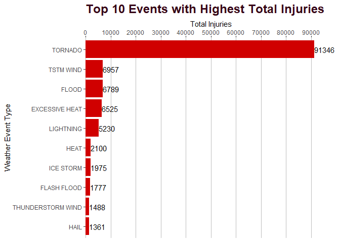

```r
> df.injuries[1:10,] %>% ggplot(aes(x = total.injuries,
+                                   y = reorder(EVTYPE, total.injuries))
+                                 ) +
+   geom_bar(stat = "identity", fill = "#d00000") +
+   scale_x_continuous(position = "top", breaks = seq(0, 90000, by = 10000),
+                      expand = c(0,0)) +
+   expand_limits(x = 100000) +
+   geom_text(aes(label = total.injuries), colour = "black", hjust = 0) +
+   labs(x = "Total Injuries", y = "Weather Event Type",
+        title = "Top 10 Events with Highest Total Injuries") +
+   theme(plot.title = element_text(colour = "#370617", size = 18,
+                                   face = "bold"),
+         panel.background = element_blank(),
+         panel.grid.major.x = element_line("grey"))
```

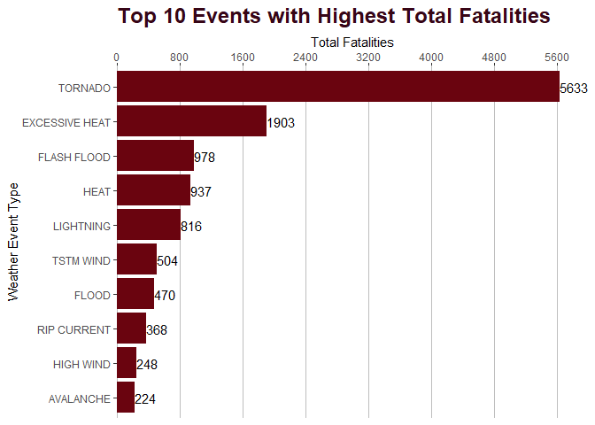

```r
> df.fatalities[1:10,] %>% ggplot(aes(x = total.fatalities,
+                                     y = reorder(EVTYPE, total.fatalities))
+                                 ) +
+   geom_bar(stat = "identity", fill = "#6a040f") +
+   scale_x_continuous(position = "top", breaks = seq(0, 6000, by = 800),
+                      expand = c(0,0)) +
+   expand_limits(x = 6000) +
+   geom_text(aes(label = total.fatalities), colour = "black", hjust = 0) +
+   labs(x = "Total Fatalities", y = "Weather Event Type",
+        title = "Top 10 Events with Highest Total Fatalities") +
+   theme(plot.title = element_text(colour = "#370617", size = 18,
+                                   face = "bold"),
+         panel.background = element_blank(),
+         panel.grid.major.x = element_line("grey"))
```

## Weather Events and economy

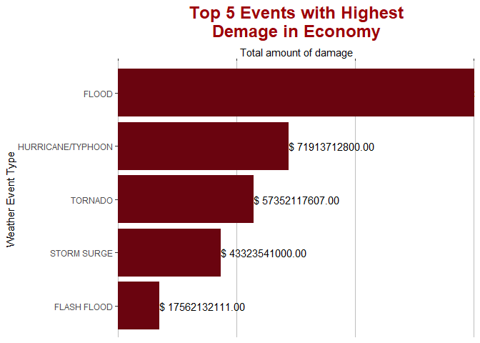

```r
> df.damage.amount[1:5,] %>% ggplot(aes(x = TOTAL.DMG.EVTYPE,
+                                     y = reorder(EVTYPE, TOTAL.DMG.EVTYPE))
+                                 ) +
+   geom_bar(stat = "identity", fill = "#6a040f") +
+   scale_x_continuous(position = "top",
+                      expand = c(0,0)) +
+   expand_limits(x = 2500000000) +
+   geom_text(aes(label = sprintf("$ %0.2f", TOTAL.DMG.EVTYPE)),
+             colour = "black", hjust = 0) +
+   labs(x = "Total amount of damage", y = "Weather Event Type",
+        title = "Top 5 Events with Highest\nDemage in Economy") +
+   theme(plot.title = element_text(colour = "#9d0208", size = 18, face = "bold",
+                                   hjust = 0.5),
+         panel.background = element_blank(),
+         panel.grid.major.x = element_line("grey"),
+         axis.text.x = element_blank())
```